# RepData_PeerAssessment_1

John D Phillips

December 13, 2014

## Loading and preprocessing the data

The steps needed to load the data are:

1. Change to the directory where the zip file resides

   You will need to edit this if you want to run the Rmd file on your own computer.

```r
setwd("/Users/john/classes/reproducibleResearch/RepData_PeerAssessment1")
```

2. Confirm that the working directory is set properly

   I’m not very proficient with R so I wanted to confirm that the working directory had actually been set properly. You may want to delete this step if you feel it is unnecessary.

```r
getwd()
```

```
## [1] "/Users/john/classes/reproducibleResearch/RepData_PeerAssessment1"
```

3. Unzip and read the activity into a local variable

   The local variable is acivityData. Each record has 3 fields

   steps - either the integer step count, or NA

   date - the year, month, and day in YYYY-MM-DD format

   interval - the 5 minute time interval hour and minute in (H)(H)M(M) format. It is coded as H*100+M without leading zeros. The first hour of the day is coded as zero (12:00AM), and the last hour of the day is coded as 23 (11:00PM).

```r
unzip("activity.zip")
activityData <- read.csv("activity.csv")
activityData[1:5,1:3]
```

```
##   steps       date interval
## 1    NA 2012-10-01        0
## 2    NA 2012-10-01        5
## 3    NA 2012-10-01       10
## 4    NA 2012-10-01       15
## 5    NA 2012-10-01       20
```

## Determine the Mean and Median number of steps taken each day

1. Determine the unique dates in the data set

```r
dates <- levels(activityData$date)
n <- length(dates); n
```

```
## [1] 61
```

2. Determine the number of steps taken for each day

```r
steps <- NULL
for (i in 1:n) {
    index <- activityData$date == dates[i]
    steps[[i]] <- sum(activityData$steps[index])
}
```

3. Plot the histogram of the number of steps per day

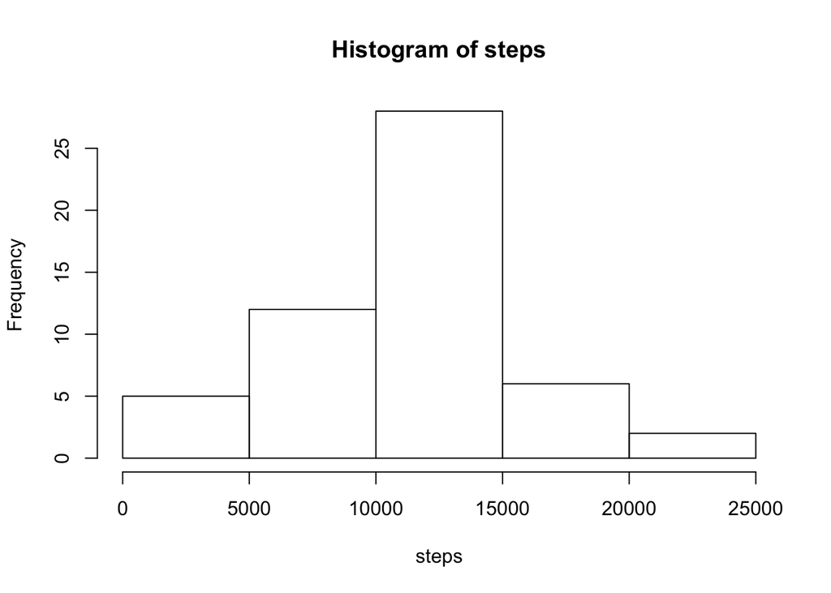

```r
hist(steps)
```

```r
steps
```

```
##  [1]    NA   126 11352 12116 13294 15420 11015    NA 12811  9900 10304
## [12] 17382 12426 15098 10139 15084 13452 10056 11829 10395  8821 13460
## [23]  8918  8355  2492  6778 10119 11458  5018  9819 15414    NA 10600
## [34] 10571    NA 10439  8334 12883  3219    NA    NA 12608 10765  7336
## [45]    NA    41  5441 14339 15110  8841  4472 12787 20427 21194 14478
## [56] 11834 11162 13646 10183  7047    NA
```

4. Since the data contains some NA values, we must now determine how the NA values are to be dealt with. In the first analysis, we will simply drop the missing values and calculate the mean and median.

```r
mean(steps,na.rm=TRUE)
```

```
## [1] 10766.19
```

```r
median(steps,na.rm=TRUE)
```

```
## [1] 10765
```

## What is the average daily activity pattern?

1. Determine the unique 5 minute intervalse in the data set

```r
intervals <- unique(activityData$interval)
n <- length(intervals); n
```

```
## [1] 288
```

```r
intervalSteps <- NULL
for (i in 1:n) {
    index <- activityData$interval == intervals[i]
    intervalSteps[[i]] <- median(activityData$steps[index],na.rm=TRUE)
}
intervalSteps
```

```
##   [1]  0  0  0  0  0  0  0  0  0  0  0  0  0  0  0  0  0  0  0  0  0  0  0
##  [24]  0  0  0  0  0  0  0  0  0  0  0  0  0  0  0  0  0  0  0  0  0  0  0
##  [47]  0  0  0  0  0  0  0  0  0  0  0  0  0  0  0  0  0  0  0  0  0  0  0
##  [70]  0  0  0  0  0  0  0  0  0  0  0  0  0  8 13  7 13 14  0  0 12  0  0
##  [93] 15 19 19 28 41 25 32 13 45 33 37 19 51 60 16 43 20  8 31 15 16  0  0
## [116]  0  0  0  0  0  0  0  0  0  0  0  0  0  0  0  0  0  0  0  0  0  0  0
## [139]  0  0  0  0  0  0  0  0  6 10  0  0  0  0  0  0  0  0  0  0  0  0  0
## [162]  0  0  0  0  0  0  0  0  0  0  0  0  0  0  0  0  0  0  0  0  0  0  0
## [185]  0  0  0  0  0  0  0  0  0  0  0  0  0  0  0  0  0  0  0  0  0  0  0
## [208]  7  7  0  7  7 26  7  0 10 15 18 26 25 24  9 33 26 34 42 33 30 33 30
## [231]  8  8  7  0  0  0  0  0  0  0  0  0  0  0  0  0  0  0  0  0  0  0  0
## [254]  0  0  0  0  0  0  0  0  0  0  0  0  0  0  0  0  0  0  0  0  0  0  0
## [277]  0  0  0  0  0  0  0  0  0  0  0  0
```

3. Plot the time series of the number of steps per interval

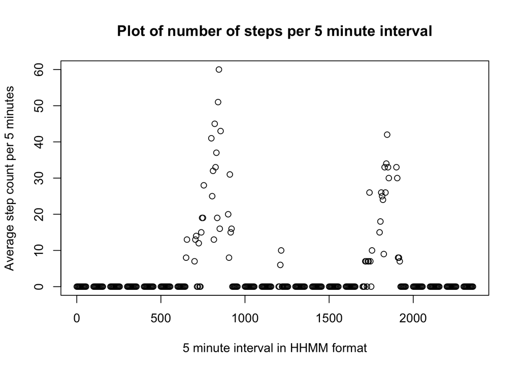

```r
plot.default(intervals,intervalSteps,
      main='Plot of number of steps per 5 minute interval',
      xlab='5 minute interval in HHMM format',
      ylab='Average step count per 5 minutes')
```

## Imputing missing values

1. Noticing that there are missing values, my strategy is to make a copy of the original data and impute the median number of steps for each interval for the missing values. The first step is to count the total number of rows, and the number of rows with missing values.

```r
newActivityData <- activityData
newActivityData[1:5,1:3]
```

```
##   steps       date interval
## 1    NA 2012-10-01        0
## 2    NA 2012-10-01        5
## 3    NA 2012-10-01       10
## 4    NA 2012-10-01       15
## 5    NA 2012-10-01       20
```

```r
length(newActivityData$steps)
```

```
## [1] 17568
```

```r
length(newActivityData$steps[is.na(newActivityData$steps)])
```

```
## [1] 2304
```

2. Next the median value of the non-missing data for each interval is calculated.

```r
intervals <- unique(newActivityData$interval)
n <- length(intervals); n
```

```
## [1] 288
```

```r
intervalSteps <- NULL
for (i in 1:n) {
    index <- newActivityData$interval == intervals[i]
    intervalSteps[[i]] <- median(newActivityData$steps[index],
                                 na.rm=TRUE)
}
```

3. For each interval, find the missing values, if any, and substitute the median value for the NA.

```r
for (i in 1:n) {
    index1 <- newActivityData$interval == intervals[i]
    index2 <- is.na(newActivityData$steps)
    index <- index1 & index2
    newActivityData$steps[index] <- intervalSteps[i]
}
```

4. Plot a histogram of the new data set and calculate the new daily mean and median using the imputed values in place of the missing values.

```r
dates <- levels(newActivityData$date)
n <- length(dates); n
```

```
## [1] 61
```

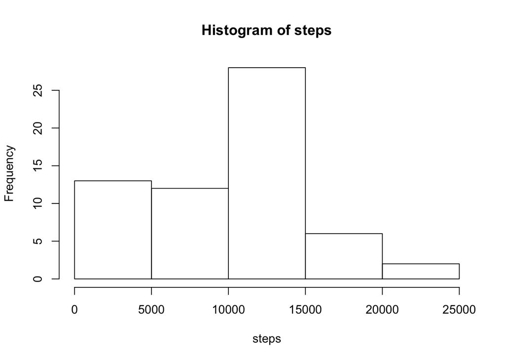

```r
steps <- NULL
for (i in 1:n) {
    index <- newActivityData$date == dates[i]
    steps[[i]] <- sum(newActivityData$steps[index])
}
hist(steps)
```

```r
mean(steps)
```

```
## [1] 9503.869
```

```r
median(steps)
```

```
## [1] 10395
```

## Determine the activity pattern for Weekdays and Weekends

1. Step one is to create a new factor variable with two levels, weekday, and weekend.

```r
newActivityData$weekday <- weekdays(as.Date(newActivityData$date))
newActivityData[1:5,1:4]
```

```
##   steps       date interval weekday
## 1     0 2012-10-01        0  Monday
## 2     0 2012-10-01        5  Monday
## 3     0 2012-10-01       10  Monday
## 4     0 2012-10-01       15  Monday
## 5     0 2012-10-01       20  Monday
```

2. Convert the weekday in Monday, Tuesday, Wednesday … format to either weekend (Saturday, Sunday) or otherwise weekday.

```r
newActivityData$weekend <- newActivityData$weekday == "Saturday" |
                           newActivityData$weekday == "Sunday"
newActivityData[1:5,1:5]
```

```
##   steps       date interval weekday weekend
## 1     0 2012-10-01        0  Monday   FALSE
## 2     0 2012-10-01        5  Monday   FALSE
## 3     0 2012-10-01       10  Monday   FALSE
## 4     0 2012-10-01       15  Monday   FALSE
## 5     0 2012-10-01       20  Monday   FALSE
```

```r
intervals <- unique(activityData$interval)
n <- length(intervals); n
```

```
## [1] 288
```

```r
weekendIntervalSteps <- NULL
weekdayIntervalSteps <- NULL
for (i in 1:n) {
    index <- newActivityData$interval == intervals[i] &
             newActivityData$weekend == TRUE
    weekendIntervalSteps[[i]] <- median(newActivityData$steps[index])
    index <- newActivityData$interval == intervals[i] &
             newActivityData$weekend == FALSE
    weekdayIntervalSteps[[i]] <- median(newActivityData$steps[index])
}
weekendIntervalSteps
```

```
##   [1]  0.0  0.0  0.0  0.0  0.0  0.0  0.0  0.0  0.0  0.0  0.0  0.0  0.0  0.0
##  [15]  0.0  0.0  0.0  0.0  0.0  0.0  0.0  0.0  0.0  0.0  0.0  0.0  0.0  0.0
##  [29]  0.0  0.0  0.0  0.0  0.0  0.0  0.0  0.0  0.0  0.0  0.0  0.0  0.0  0.0
##  [43]  0.0  0.0  0.0  0.0  0.0  0.0  0.0  0.0  0.0  0.0  0.0  0.0  0.0  0.0
##  [57]  0.0  0.0  0.0  0.0  0.0  0.0  0.0  0.0  0.0  0.0  0.0  0.0  0.0  0.0
##  [71]  0.0  0.0  0.0  0.0  0.0  0.0  0.0  0.0  0.0  0.0  0.0  0.0  0.0  0.0
##  [85]  0.0  0.0  7.0  0.0  0.0  9.0  0.0  0.0  0.0 11.5 12.0  9.0 33.5 16.5
##  [99] 19.0 26.0 45.0 45.5 37.0 19.0 58.0 62.5 20.0 49.0 20.0  4.0 59.0 38.0
## [113] 29.5  0.0  0.0  0.0  0.0  0.0  0.0  0.0  0.0  0.0  0.0  0.0  0.0  0.0
## [127]  0.0  0.0  0.0  0.0  0.0  8.5  0.0  2.5  0.0  0.0  0.0  0.0  3.0  5.0
## [141]  0.0  0.0  3.0 36.5 31.5 38.0  6.0 31.0 19.0  0.0  0.0  5.0  0.0  0.0
## [155] 17.0  4.5  4.0  0.0  0.0  0.0  7.0 15.5  0.0  0.0  0.0 32.5 22.5 59.0
## [169]  7.5 16.0 15.0  5.0  0.0  5.5  6.5  0.0  0.0  0.0  0.0  6.0  0.0  0.0
## [183]  0.0  0.0  0.0  0.0  0.0  0.0  0.0  0.0  0.0  0.0  0.0  0.0  0.0  0.0
## [197]  4.5  0.0  6.0  0.0 18.5 46.0 11.0  0.0  0.0  0.0  0.0  7.0 19.0 38.0
## [211] 10.0 10.0 26.0 14.5  0.0 10.0 42.5 51.0 50.0 25.0 24.0  4.5 38.5 16.0
## [225]  4.0 40.0  7.5 31.5 28.5 30.0  4.0  8.0  7.0  0.0  0.0  0.0  0.0  0.0
## [239]  0.0  0.0  0.0  0.0 11.0  0.0  0.0  0.0  0.0  0.0  0.0  0.0 11.5  0.0
## [253]  0.0  0.0  0.0  0.0  0.0  0.0  0.0  0.0  0.0  0.0  0.0  0.0  0.0  0.0
## [267]  0.0  0.0  0.0  0.0  0.0  0.0  0.0  0.0  0.0  0.0  0.0  0.0  0.0  0.0
## [281]  0.0  0.0  0.0  0.0  0.0  0.0  0.0  0.0
```

```r
weekdayIntervalSteps
```

```
##   [1]  0  0  0  0  0  0  0  0  0  0  0  0  0  0  0  0  0  0  0  0  0  0  0
##  [24]  0  0  0  0  0  0  0  0  0  0  0  0  0  0  0  0  0  0  0  0  0  0  0
##  [47]  0  0  0  0  0  0  0  0  0  0  0  0  0  0  0  0  0  0  0  0  0  0  0
##  [70]  0  0  0  0  0  0  0  0  0  0  0  0  0 10 14  7 13 14 11  2 12  0  0
##  [93] 15 19 19 28 41 25 32 13 45 33 37 19 51 60 16 43 20  8 27 15 16  0  0
## [116]  0  0  0  0  0  0  0  0  0  0  0  0  0  0  0  0  0  0  0  0  0  0  0
## [139]  0  0  0  0  0  0  0  0  6 10  0  0  0  0  0  0  0  0  0  0  0  0  0
## [162]  0  0  0  0  0  0  0  0  0  0  0  0  0  0  0  0  0  0  0  0  0  0  0
## [185]  0  0  0  0  0  0  0  0  0  0  0  0  0  0  0  0  0  0  0  0  0  0  0
## [208]  7  7  0  7  7 26  7  0 10  7 17 26 25 24  9 33 26 34 42 33 30 33 30
## [231]  8  8  7  0  0  0  0  0  0  0  0  0  0  0  0  0  0  0  0  0  0  0  0
## [254]  0  0  0  0  0  0  0  0  0  0  0  0  0  0  0  0  0  0  0  0  0  0  0
## [277]  0  0  0  0  0  0  0  0  0  0  0  0
```

3. Plot the time series of the number of steps per interval for weekends and weekdays

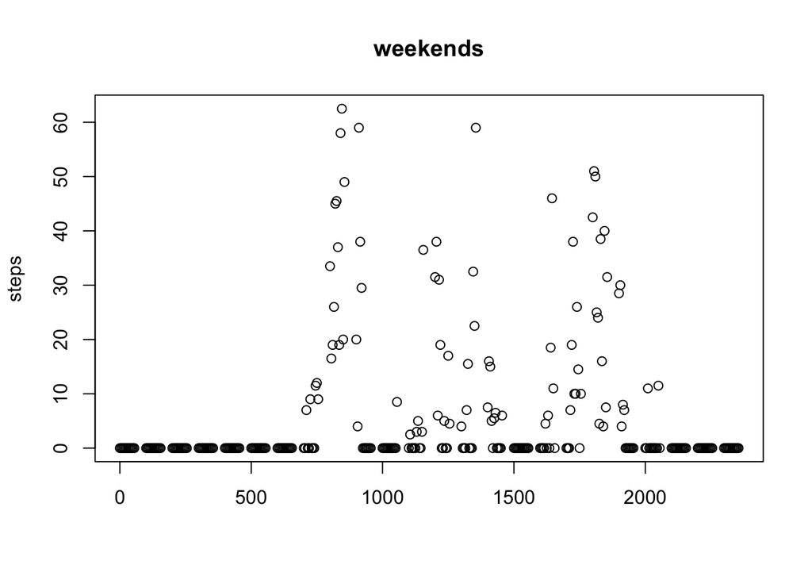

```r
plot.default(intervals,weekendIntervalSteps,
      main='weekends',
      sub='',
      xlab='',
      ylab='steps')
```

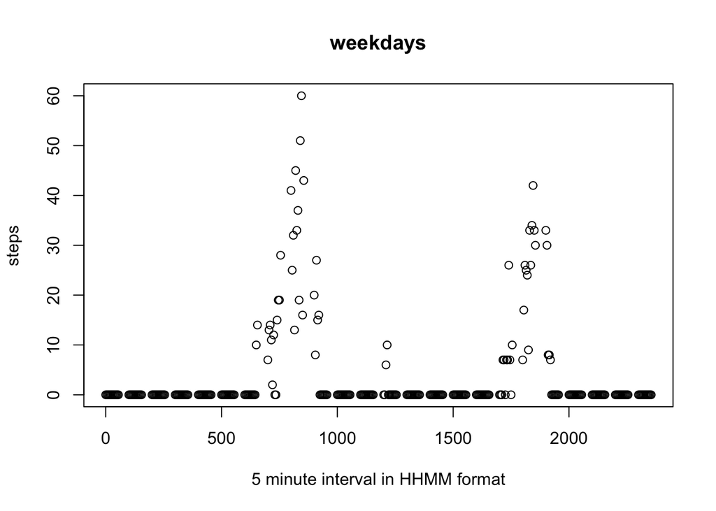

```r
plot.default(intervals,weekdayIntervalSteps,
      main='weekdays',
      sub='',
      xlab='5 minute interval in HHMM format',
      ylab='steps')
```